# Final Assignment

Due 1/8/2018

**Instructions:**  
1. Please rename your final assignment rmd file as - `finalAssign_name.rmd`.  
2. Fill in your code in the relevant code execution boxes.  
3. Please avoid plagiarism - do not share your answers with other students!  
4. Use the encryption guide (see moodle) to encrypt your final rmd file and name it `finalAssign_name_rmd_crypt`  
5. Use the encryption guide to encrypt also your HTML file and name it `finalAssign_name_html_crypt`  
6. Upload the encrypted files to the following link:  
`https://github.com/DataScienceHU/DataAnalysisR/tree/master/finalAssignment/finalAssignment_submission/`

# 52414 Final Assignment

[figure not shown]

**The final assignment is based on an article published by [*FiveThirtyEight*](http://fivethirtyeight.com/). In the article, the author investigated differences between male and female superheroes in comic books: [*Comic Books Are Still Made By Men, For Men And About Men*](https://fivethirtyeight.com/features/women-in-comic-books/). In this assignment, you will not only try to reproduce some of the findings with a more up-do-date data, but will also dive deeper into the data to provide meaningful insights backed by statistical analysis.**

1. Do not use libraries outside of the required libraries.
2. It is recommended to read the 538 article.

### 1) Data Loading and Cleaning

*Load the `heroes`,`powers`, and the `details` datasets.*

```r
df_heroes <- read.csv(("C:/Users/user/Desktop/heroes.csv"), stringsAsFactors=FALSE)
df_powers <- read.csv(("C:/Users/user/Desktop/powers.csv"), stringsAsFactors=FALSE)
df_details <- readLines("C:/Users/user/Desktop/details.txt")
```

1. Using kable, show the first 10 rows of the `heroes` dataframe.

```r
kable(df_heroes[1:10,])
```

[output not shown]

```r
A<-sum(str_count(df_heroes, pattern = "-"))
A
```

```
## [1] 1884
```

```r
B<-sum(str_count(df_heroes, pattern = "-99"))
B
```

```
## [1] 454
```

3. We would like to replace all of the above instances. Write another script that goes over the columns and replaces all the `-` to `otherNA` and `-99` to `NA`. Using kable, show the first 10 rows of the resulting dataframe.

```r
df_heroes[df_heroes=="-"]<-"otherNA"
df_heroes[df_heroes=="-99"]<-"NA"
kable(df_heroes[1:10,])
```

[output not shown]

4. Currently, the `details` data is loaded as a character vector. Parse the vector and transalte it into a dataframe containing two columns: power_name(chr) and power_score(double).

```r
df_details<- df_details[ df_details != ""]

df <- unlist(str_split(string = df_details, pattern = "\\+"))
df<-as.data.frame((matrix(df,ncol=2, byrow =T)))
names(df)<-c("power_name","power_score")
```

### 2) Exploratory Data Analysis

**We are going to concetrate our analysis on the gender disparity and representation of Comics superheroes.**

1. Make a plot of the gender distribution (total, not intersected with any other variable).

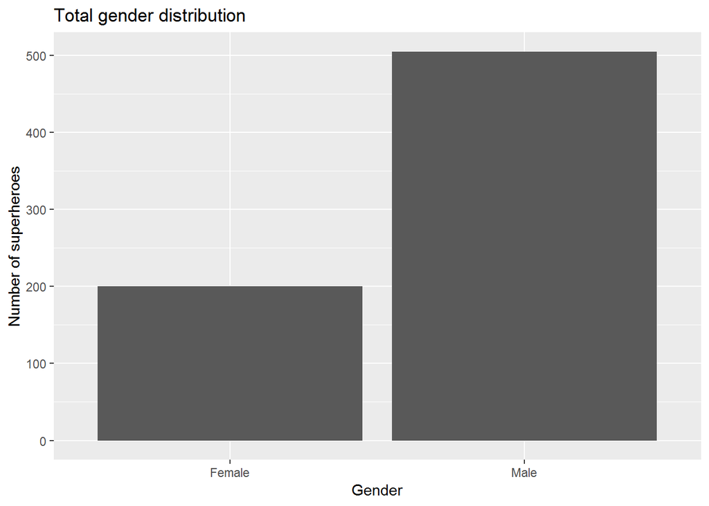

```r
df_heroes<-df_heroes%>%filter(Gender== "Male" | Gender=="Female")
df_heroes%>%ggplot(aes(Gender))+ geom_bar() + ggtitle("Total gender distribution")+ylab("Number of superheroes")
```

**For the rest of the analysis, we will concetrate only on comics by `DC Comics` and `Marvel Comics`.**

2. Make a plot comparing the gender distribution of superheroes in DC Comics vs Marvel

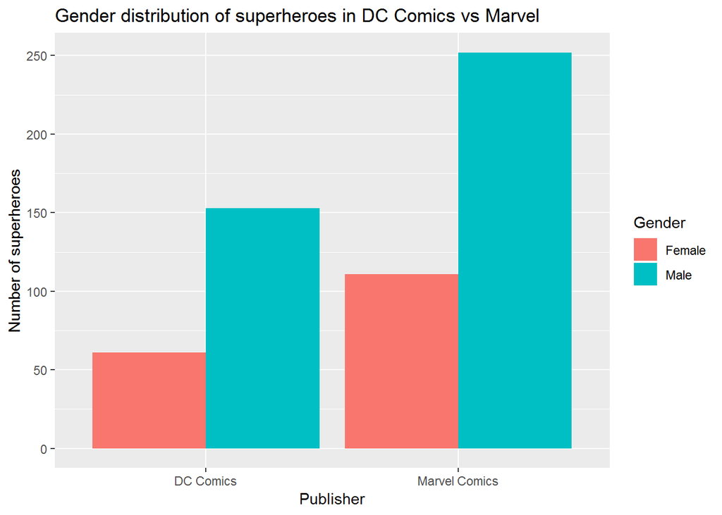

```r
df_heroes_new<-df_heroes%>%filter(Publisher== "DC Comics" | Publisher=="Marvel Comics")
df_heroes_new%>%ggplot(aes(Publisher,fill=Gender))+ geom_bar(position = "dodge")+ggtitle("Gender distribution of superheroes in DC Comics vs Marvel")+ylab("Number of superheroes")
```

```r
#In the plot we can see that there is less female superheroes in both Publishers comics.
```

3. Make the same plot as above, but this time take `Alignment` into consideration as well.

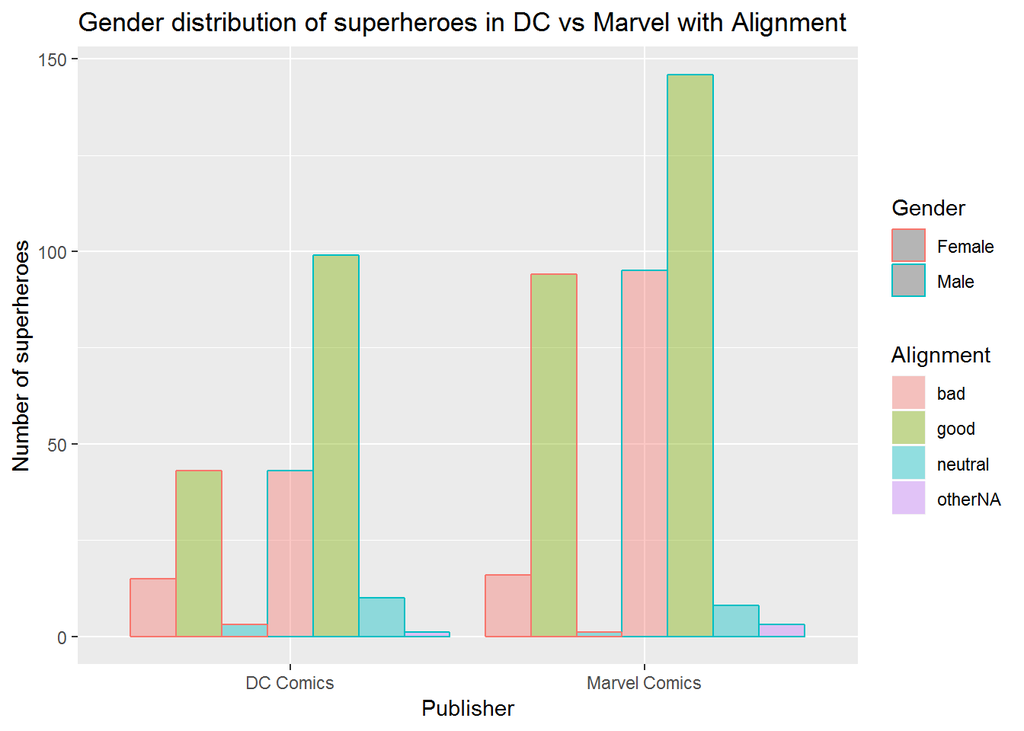

```r
df_heroes_new<-df_heroes%>%filter(Publisher== "DC Comics" | Publisher=="Marvel Comics")
df_heroes_new%>%ggplot(aes(Publisher,col= Gender, fill=Alignment))+ geom_bar(position = "dodge",alpha=0.4)+ggtitle("Gender distribution of superheroes in DC vs Marvel with Alignment ")+ylab("Number of superheroes")
```

4. Are the gender differences between the two publishers statistically significant? Use a parametric test for that.

```r
DC<-df_heroes%>%filter(Publisher== "DC Comics")
f1<-sum(DC$Gender=="Female")
m1<-sum(DC$Gender=="Male")

Marvel <-df_heroes%>%filter(Publisher== "Marvel Comics")
f2<-sum(Marvel$Gender=="Female")
m2<-sum(Marvel$Gender=="Male")

z.prop = function(f1,f2,m1,m2){
  numerator = (f1/m1) - (f2/m2)
  p.common = (f1+f2) / (m1+m2)
  denominator = sqrt(p.common * (1-p.common) * (1/m1 + 1/m2))
  z.prop.ris = numerator / denominator
  return(z.prop.ris)
}
z.prop(f1,f2,m1,m2)
```

```
## [1] -0.8247738
```

```r
#|z.prop|<1.96 We can conclude that there is no significant gender differences between the two publishers.
```